# Body Fat Prediction

GS

18/9/2021

#### Context

Lists estimates of the percentage of body fat determined by underwater weighing and various body circumference measurements for 252 men.

#### Content

- The variables listed below, from left to right, are:
- Density determined from underwater weighing
- Percent body fat from Siri’s (1956) equation
- Age (years)
- Weight (lbs)
- Height (inches)
- Neck circumference (cm)
- Chest circumference (cm)
- Abdomen 2 circumference (cm)
- Hip circumference (cm)
- Thigh circumference (cm)
- Knee circumference (cm)
- Ankle circumference (cm)
- Biceps (extended) circumference (cm)
- Forearm circumference (cm)
- Wrist circumference (cm)

(Measurement standards are apparently those listed in Benhke and Wilmore (1974), pp. 45-48 where, for instance, the abdomen 2 circumference is measured “laterally, at the level of the iliac crests, and anteriorly, at the umbilicus”.)

These data are used to produce the predictive equations for lean body weight given in the abstract “Generalized body composition prediction equation for men using simple measurement techniques”, K.W. Penrose, A.G. Nelson, A.G. Fisher, FACSM, Human Performance Research Center, Brigham Young University, Provo, Utah 84602 as listed in Medicine and Science in Sports and Exercise, vol. 17, no. 2, April 1985, p. 189. (The predictive equation were obtained from the first 143 of the 252 cases that are listed below).

[Link Kaggle](https://www.kaggle.com/fedesoriano/body-fat-prediction-dataset)

```r
library(tidyverse)
library(tidymodels)
library(GGally)
library(corrr)
library(ggcorrplot)
library(ggExtra) # marginal plots
library(gridExtra)
library(wesanderson)

theme_set(theme_bw())
```

```r
fat <- read_csv("bodyfat.csv")
```

### EDA

```r
sample_n(fat,5)
```

```
# A tibble: 5 x 15
  Density BodyFat   Age Weight Height  Neck Chest Abdomen   Hip Thigh  Knee
    <dbl>   <dbl> <dbl>  <dbl>  <dbl> <dbl> <dbl>   <dbl> <dbl> <dbl> <dbl>
1    1.03    29      67   200.   68.5  40.7 118.    106.   102.  58.2  38.8
2    1.03    30      55   184.   67.5  40.9 103     100.   104.  64.8  40.2
3    1.05    20.4    41   210.   72    38.5 107.     98.9  104.  63.5  39.8
4    1.07    13.8    50   161    66.5  37.7  98.9    84.1   94   58.5  36.6
5    1.06    16.1    57   182.   71.8  39.4 103.     96.7  101.  59.3  38.6
# ... with 4 more variables: Ankle <dbl>, Biceps <dbl>, Forearm <dbl>,
#   Wrist <dbl>
```

```r
dim(fat)
```

```
[1] 252  15
```

**Response variable: BodyFat**

```r
summary(fat)
```

```
    Density         BodyFat           Age            Weight
 Min.   :0.995   Min.   : 0.00   Min.   :22.00   Min.   :118.5
 1st Qu.:1.041   1st Qu.:12.47   1st Qu.:35.75   1st Qu.:159.0
 Median :1.055   Median :19.20   Median :43.00   Median :176.5
 Mean   :1.056   Mean   :19.15   Mean   :44.88   Mean   :178.9
 3rd Qu.:1.070   3rd Qu.:25.30   3rd Qu.:54.00   3rd Qu.:197.0
 Max.   :1.109   Max.   :47.50   Max.   :81.00   Max.   :363.1
     Height           Neck           Chest           Abdomen
 Min.   :29.50   Min.   :31.10   Min.   : 79.30   Min.   : 69.40
 1st Qu.:68.25   1st Qu.:36.40   1st Qu.: 94.35   1st Qu.: 84.58
 Median :70.00   Median :38.00   Median : 99.65   Median : 90.95
 Mean   :70.15   Mean   :37.99   Mean   :100.82   Mean   : 92.56
 3rd Qu.:72.25   3rd Qu.:39.42   3rd Qu.:105.38   3rd Qu.: 99.33
 Max.   :77.75   Max.   :51.20   Max.   :136.20   Max.   :148.10
      Hip            Thigh            Knee           Ankle          Biceps
 Min.   : 85.0   Min.   :47.20   Min.   :33.00   Min.   :19.1   Min.   :24.80
 1st Qu.: 95.5   1st Qu.:56.00   1st Qu.:36.98   1st Qu.:22.0   1st Qu.:30.20
 Median : 99.3   Median :59.00   Median :38.50   Median :22.8   Median :32.05
 Mean   : 99.9   Mean   :59.41   Mean   :38.59   Mean   :23.1   Mean   :32.27
 3rd Qu.:103.5   3rd Qu.:62.35   3rd Qu.:39.92   3rd Qu.:24.0   3rd Qu.:34.33
 Max.   :147.7   Max.   :87.30   Max.   :49.10   Max.   :33.9   Max.   :45.00
    Forearm          Wrist
 Min.   :21.00   Min.   :15.80
 1st Qu.:27.30   1st Qu.:17.60
 Median :28.70   Median :18.30
 Mean   :28.66   Mean   :18.23
 3rd Qu.:30.00   3rd Qu.:18.80
 Max.   :34.90   Max.   :21.40
```

```r
# No NAs
```

```r
fat <- fat %>%
  mutate(Weight = round(Weight * 0.453592, digits = 2),
         Height = round(Height * 2.54, digits = 2))
```

[figure not shown]

[output not shown]

[output not shown]

[figure not shown]

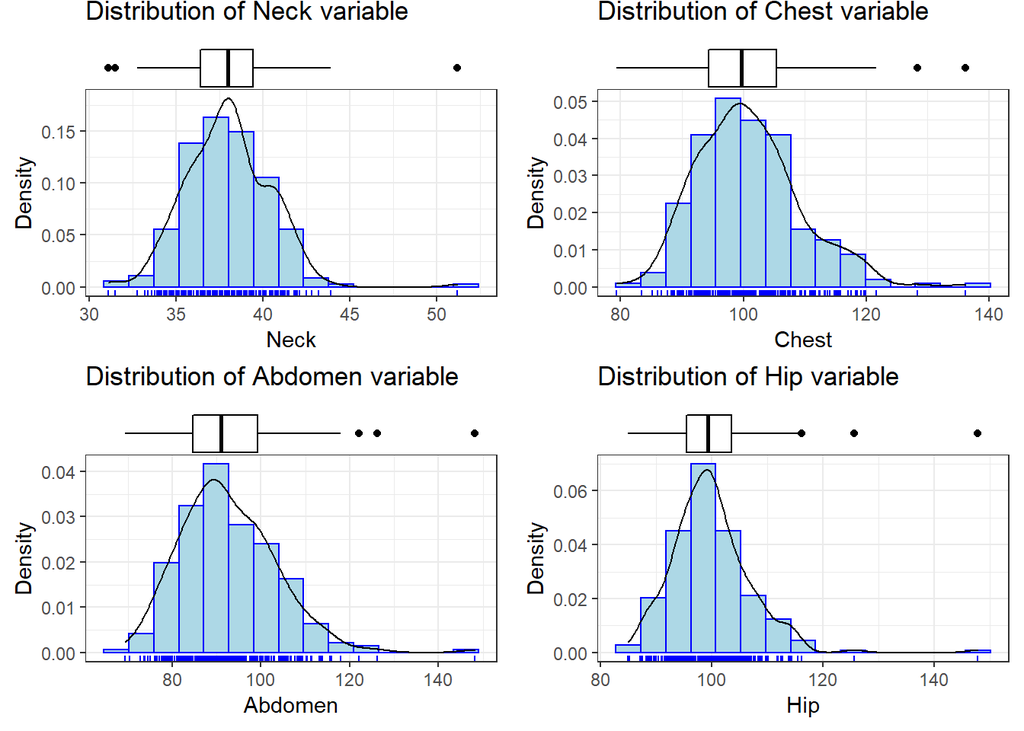

[figure not shown]

[figure not shown]

```r
ggpairs(fat)
```